# Construção de modelos causais

Diogo Melo , Paulo Inácio Prado  
2026-11-11

# Relembrando regressão múltipla

Na regressão linear múltipla, o valor esperado da resposta é uma **combinação linear** das variáveis preditoras:

$$\begin{aligned}
y_i &\sim Normal(\mu_i, \sigma) \\
\mu_i &= \sum_j \beta_j x_{ij} \\
\end{aligned}$$

Este modelo é ajustado encontrando os valores de $\beta_j$ que fornecem a melhor predição da resposta esperada (ou média) $\mu_i$. Se os preditores são causas independentes da resposta, os coeficientes estimados $\beta_j$ expressam os efeitos isolados de cada preditor sobre a resposta. Você pode verificar isso criando uma variável Gaussiana com um valor médio que é a soma de dois preditores independentes:

```r
set.seed(42)
x1 <- runif(1000)
x2 <- runif(1000)
y <- rnorm(1000, mean = x1 + x2, sd = 0.5)
```

e então comparando os coeficientes da regressão múltipla com aqueles da regressão simples em cada preditor individual:

```r
coef( lm(y ~ x1 + x2) )
coef( lm(y ~ x1) )
coef( lm(y ~ x2) )
```

O que acontece se os preditores não são independentes? Simule dois preditores que compartilham uma causa comum, ou seja, uma variável desconhecida $u$. A causa comum cria uma correlação entre os dois preditores:

```r
u <- runif(100)
x1 <- rnorm(100, mean = u, sd =0.1)
x2 <- rnorm(100, mean = u, sd =0.1)
y <-  rnorm(100, mean = x1 + x2, sd =0.1)
plot(x2 ~ x1)
```

E agora os coeficientes de cada preditor no modelo múltiplo são muito menores que seus efeitos isolados (estimados a partir de regressões simples):

```r
coef( lm(y ~ x1 + x2) )
coef( lm(y ~ x1) )
coef( lm(y ~ x2) )
```

Isso acontece porque os coeficientes de uma regressão múltipla expressam **efeitos parciais ou controlados**, ou seja, os efeitos diretos de cada preditor quando todos os outros preditores são mantidos constantes (e não são contabilizados por outros preditores). Assim, os coeficientes de uma regressão múltipla para um preditor $x_1$ correspondem aos coeficientes de uma regressão simples da resposta em função dos **resíduos** de $x_1$ em relação a todos os outros preditores $x_i$.

Calcule os resíduos dos preditores $x_1$ e $x_2$ um em relação ao outro e plote $y$ em função de cada uma dessas variáveis residuais:

```r
x1_res <- residuals( lm(x1 ~ x2) )
x2_res <- residuals( lm(x2 ~ x1) )

par(mfcol = c(2,2))
plot(y ~ x1, main = "y ~ x1")
abline( lm(y ~ x1) )
plot(y ~ x1_res, main = "y ~ x1|x2", xlab = "residuals of x1 ~ x2")
abline( lm(y ~  x1_res))
plot(y ~ x2, main = "y ~ x2")
abline( lm(y ~x2) )
plot(y ~ x2_res, main = "y ~ x2|x1", xlab = "residuals of x2 ~ x1")
abline( lm(y ~  x2_res))
par(mfcol = c(1,1))
```

Os coeficientes de $x_1$ e $x_2$ na regressão múltipla são as inclinações das linhas na linha inferior dos gráficos na figura acima. Essas inclinações são menores que as da regressão linear com os valores brutos dos preditores (primeira linha de gráficos acima). Você pode verificar isso comparando os coeficientes dessas regressões com os coeficientes da regressão múltipla:

```r
coef( lm(y ~ x1 + x2) )
coef( lm(y ~x1_res) )
coef( lm(y ~x2_res) )
```

Em resumo, coeficientes de regressão múltipla expressam efeitos diretos, controlados por todos os outros preditores. A inferência dos caminhos causais por trás desses efeitos parciais não é trivial, porque tais efeitos podem ter diferentes significados. Variáveis independentes em uma regressão múltipla podem desempenhar diferentes papéis, como confundidores, mediadores ou proxies. Se você entender isso, pode inferir alguns aspectos importantes dos padrões causais a partir de diferentes modelos lineares.

# Bons controles

Ao ajustar modelos causais, frequentemente é necessário adicionar covariáveis a um modelo linear para identificar corretamente o efeito de interesse. Isso significa executar uma regressão múltipla na qual um dos coeficientes está relacionado ao caminho causal de interesse, e os outros são adicionados ao modelo para bloquear caminhos não-causais. Muitos dos exemplos neste tutorial são de [Cinelli, Carlos, Andrew Forney, and Judea Pearl. “A crash course in good and bad controls.” Sociological Methods & Research (2021): 00491241221099552.](https://ftp.cs.ucla.edu/pub/stat_ser/r493.pdf)

Por exemplo, nos seguintes DAGs, onde X, Y e Z são observados, e U não é observado:

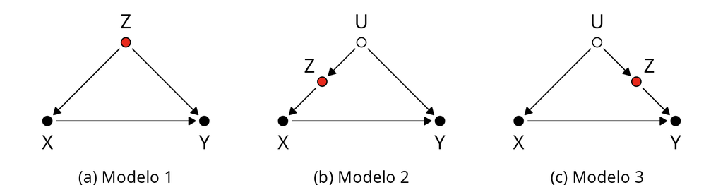

Sempre há uma causa comum compartilhada entre X e Y, e estimar o efeito de X em Y requer bloquear este caminho não-causal, incluindo a causa compartilhada (ou variável de confusão) como controle no modelo. A variável Z pode ser usada como covariável em todos os casos, mesmo na presença do confundidor não observado U.

Vamos verificar isso simulando o DAG no modelo 2:

```r
N = 100
U = rnorm(N)
b_zu = 0.5
Z = rnorm(N, b_zu * U)
b_xz = 0.8
X = rnorm(N, b_xz * Z)
b_yu = 1
b_yx = 1
Y = rnorm(N, b_yu * U + b_yx * X)

lm(Y ~ X) |> coef() # Enviesado pelo caminho não-causal, efeito de X é superestimado
lm(Y ~ X + Z) |> coef() # Não enviesado, efeito de X está correto e igual a b_yx
```

## O critério da porta dos fundos

Por que Z funciona como controle no modelo 2, mesmo sem observarmos U? No modelo 2 existem dois caminhos entre X e Y[^1]:

- X → Y: o caminho causal, que queremos estimar;
- X ← Z ← U → Y: um caminho não-causal, que entra em X por uma seta que **aponta para X** (uma “porta dos fundos”).

O caminho pela porta dos fundos é composto de pipes e forks, e por isso está aberto, a não ser que condicionemos em alguma variável ao longo dele. Não podemos condicionar em U, que não foi observado, mas condicionar em Z já fecha o caminho. Esse é o **critério da porta dos fundos**: para estimar o efeito causal de X em Y, precisamos de um conjunto de covariáveis que (1) bloqueie todos os caminhos entre X e Y que começam com uma seta apontando para X e (2) não contenha descendentes de X.

**Questão**: Liste os caminhos entre X e Y nos modelos 1 e 3 e verifique que Z satisfaz o critério da porta dos fundos nos dois casos.

## A falácia da tabela 2

O modelo `lm(Y ~ X + Z)` também estima um coeficiente para Z. É tentador interpretá-lo como o efeito causal de Z em Y, e é isso que muitos artigos fazem ao apresentar todos os coeficientes de um modelo numa mesma tabela (a “tabela 2” de [Westreich e Greenland, 2013](https://doi.org/10.1093/aje/kws412)). Vamos repetir a simulação do modelo 2 com uma amostra maior:

```r
set.seed(42)
N = 1000
U = rnorm(N)
Z = rnorm(N, 0.5 * U)
X = rnorm(N, 0.8 * Z)
Y = rnorm(N, U + X)

lm(Y ~ X + Z) |> coef()
```

No modelo 2, Z afeta Y apenas através de X, então o efeito causal (total) de Z em Y é $0{,}8 \times 1 = 0{,}8$, e o efeito direto é zero. O coeficiente de Z no modelo não é nenhum dos dois.

**Questão**: De onde vem o valor estimado para o coeficiente de Z? (Dica: quais caminhos entre Z e Y estão abertos quando condicionamos em X?)

**Questão**: Ajuste `lm(Y ~ Z)`. Essa regressão estima o efeito total de Z em Y? Existe algum conjunto de covariáveis observadas que permitiria estimar esse efeito? Use o critério da porta dos fundos, tratando Z como a exposição.

Um modelo construído para estimar o efeito de X em Y estima o efeito de X em Y. Os coeficientes das variáveis de controle, em geral, não têm interpretação causal.

A mesma lógica se aplica se o confundidor é mediado por outra variável M:

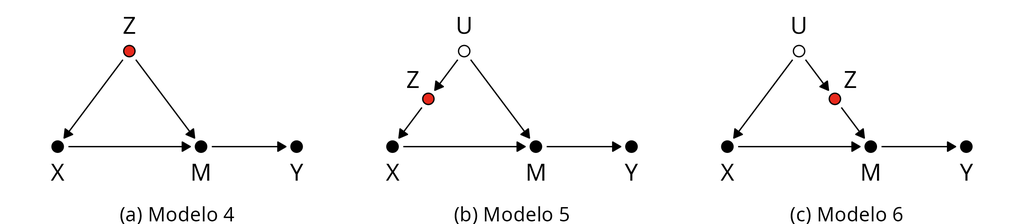

Z deve ser adicionado como covariável em todos estes casos.

**Questão**: Se estamos interessados no efeito de X em Y, M também poderia ser adicionado ao modelo? Explique.

**Exercício**: Escolha um destes DAGs e execute uma simulação, explore o efeito de adicionar Z ou M como covariáveis.

## Controles razoavelmente bons

Algumas covariáveis podem ser adicionadas a um modelo não para evitar viés, mas para aumentar a precisão. Por exemplo, no seguinte DAG:

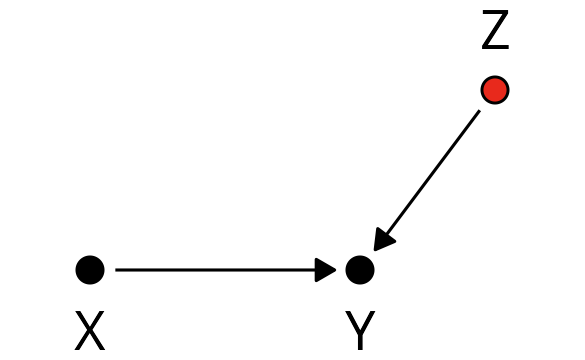

Neste caso, adicionar Z como covariável aumenta a precisão da estimativa do efeito de X em Y.

Novamente, vamos verificar usando simulações e então comparar os intervalos de confiança dos efeitos estimados de X em Y:

```r
set.seed(2)
N = 200
X = rnorm(N)
Z = rnorm(N)
b_yx = 1
b_yz = 2
Y = rnorm(N, b_yx * X + b_yz * Z)
## Ajusta modelos sem e com a variável Z como covariável
m_yx = lm(Y ~ X)
m_yxz = lm(Y ~ X + Z)

# Intervalos de confiança do coeficiente de X
confint(m_yx)["X",]
confint(m_yxz)["X",]

# Plot do intervalo de confiança do coeficiente de X nos dois modelos
plot(1:2, c(coef(m_yx)["X"], coef(m_yxz)["X"]),
      ylim = c(-1, 3), xlim = c(0, 3),
      xlab = "Modelo", ylab = "Coeficiente de X",
      xaxt = "n", pch = 19, col = 2)
arrows(1, confint(m_yx)["X",1], 1, confint(m_yx)["X",2], angle = 90, code = 3, length = 0.1)
arrows(2, confint(m_yxz)["X",1], 2, confint(m_yxz)["X",2], angle = 90, code = 3, length = 0.1)
axis(1, at = 1:2, labels = c("Sem Z", "Com Z"))
```

Os intervalos de confiança do coeficiente de X têm a mesma média, mas variâncias diferentes. Isso acontece porque adicionar a covariável remove parte da variação em Y que não está associada com X, o que diminui a variância do efeito estimado de X (ou aumenta sua precisão, que é a mesma coisa).

**Questão**: E se Z é uma causa de X, não de Y. Adicionar Z à regressão ajudaria neste caso?

# Maus controles

Duas classes de maus controles são o viés pós-tratamento ou viés de supercontrole, e a amplificação de viés.

Nos seguintes DAGs, controlar por Z levaria a uma subestimativa do efeito de X em Y.

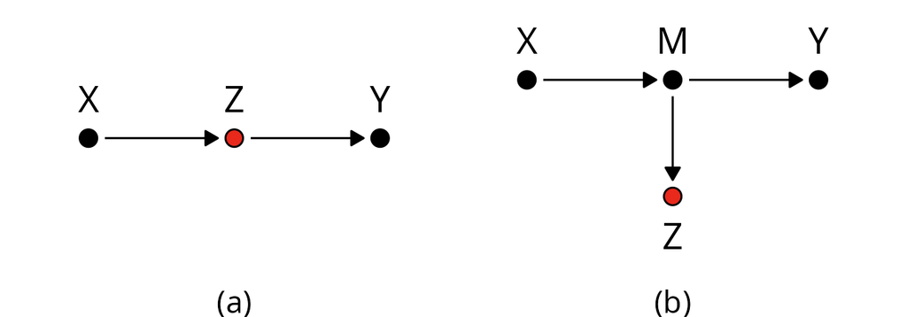

No DAG (a), Z é um mediador: condicionar em Z bloqueia o caminho causal. No DAG (b), Z não está no caminho entre X e Y, mas é um descendente do mediador M (por exemplo, uma medida imperfeita de M) e, ao condicionar em Z, bloqueamos parcialmente o caminho causal. Vamos simular o DAG (b):

```r
set.seed(3)
N = 1000
X = rnorm(N)
M = rnorm(N, 0.8 * X)
Y = rnorm(N, M)
Z = rnorm(N, M, 0.5) # Z é uma medida ruidosa de M

lm(Y ~ X) |> coef()     # Efeito total de X em Y (0.8)
lm(Y ~ X + Z) |> coef() # Efeito de X subestimado
lm(Y ~ X + M) |> coef() # Caminho causal completamente bloqueado
```

**Questão**: O que acontece com a estimativa do efeito de X quando a medida Z fica mais precisa (por exemplo, `sd = 0.1`) ou menos precisa (`sd = 2`)? Por quê?

No seguinte caso, controlar por Z levaria a um aumento no viés causado pela variável não observada U.

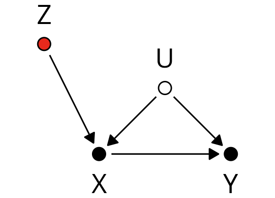

**Exercício**: Simule o exemplo de amplificação de viés e verifique o efeito de incluir a variável Z no modelo. Você pode começar com:

```r
set.seed(4)
N = 1000
Z = rnorm(N)
U = rnorm(N)
b_xz = 2
X = rnorm(N, b_xz * Z + U)
Y = rnorm(N, X + U) # efeito verdadeiro de X em Y é 1
```

Compare as estimativas de `lm(Y ~ X)` e `lm(Y ~ X + Z)`. Depois, repita a simulação com valores diferentes de `b_xz` (por exemplo, 0, 1 e 5). Como o viés muda? Por que o viés aumenta quando incluímos Z? (Dica: pense em qual parte da variação de X sobra para estimar o efeito depois que removemos a parte explicada por Z.)

O problema piora quando há muitas covariáveis. [Pearl (2011)](https://doi.org/10.1093/aje/kwr352) mostra que, ao condicionarmos em várias covariáveis em sequência, a amplificação do viés se acumula e cresce sempre, enquanto a redução do viés de confusão pode ser parcialmente cancelada, porque os efeitos de cada covariável podem ter sinais opostos. Por isso, a amplificação pode acumular mais rápido que a redução de viés. Isso é um argumento contra a estratégia de “incluir tudo o que foi medido” no modelo: covariáveis que afetam fortemente X, mas não Y, podem fazer mais mal do que bem quando restam confundidores não observados.

## AIC e significância não vão ajudar você

Para explorar o efeito de uma variável de controle ruim, vamos simular um colisor:

```r
# DAG : X -> Z <- Y
N = 200
X = rnorm(N)
Y = rnorm(N)
Z = rnorm(N, Y + X)

m1 = lm(Y~X)   # Modelo correto
m2 = lm(Y~X+Z) # Modelo incluindo o colisor
```

Primeiro, vamos olhar para a significância das variáveis em ambos os modelos:

```r
summary(m1)
summary(m2)
```

Não incluir Z dá a estimativa correta de nenhum efeito de X em Y, mas o modelo incluindo Z nos diz que tanto X quanto Z têm efeitos significativos em Y. Por que isso?

Muitos pesquisadores interpretariam os resultados significativos no modelo 2 como evidência de que tanto X quanto Z afetam Y, não cometa este erro! Modelos estatísticos são cegos para causas, eles apenas capturam associações.

E quanto ao AIC? A comparação de modelos identificaria o modelo correto?

```r
library(bbmle)
AICctab(m1, m2, mnames = c("Correto", "Enviesado"),
        base=TRUE, weights = TRUE, nobs = N)
```

O modelo enviesado também é selecionado pelo AIC. Isso não é surpreendente, já que a inclusão do colisor aumenta a informação disponível sobre Y, e assim faz melhores predições.

**A única maneira de identificar o possível viés é tendo um modelo científico claro.**

## Viés de seleção: condicionando no colisor sem perceber

Não é preciso incluir o colisor como covariável para condicionar nele. Se a forma como os dados foram obtidos depende de um colisor, a própria amostra já está condicionada.

Imagine que queremos saber se o tamanho corporal está associado à coloração (por exemplo, cores de advertência) em uma família de anfíbios, usando registros de coleções de museus. Suponha que tamanho e coloração sejam independentes, mas que indivíduos maiores e mais coloridos sejam mais fáceis de detectar e, portanto, de coletar:

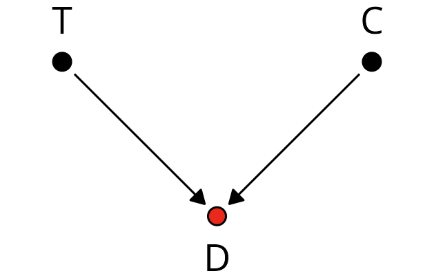

Vamos simular a população completa e a amostra de indivíduos detectados (D = 1):

```r
set.seed(7)
N = 1000
inv_logit = function(x) 1 / (1 + exp(-x))
Tam = rnorm(N) # tamanho corporal
Cor = rnorm(N) # intensidade da coloração
D = rbinom(N, 1, inv_logit(-2 + 2 * Tam + 2 * Cor)) # detecção

lm(Cor ~ Tam) |> coef()                 # População completa
lm(Cor ~ Tam, subset = D == 1) |> coef() # Apenas indivíduos coletados

plot(Cor ~ Tam, col = ifelse(D == 1, "red", "gray"), pch = 19,
     xlab = "Tamanho corporal", ylab = "Coloração")
abline(lm(Cor ~ Tam), lwd = 2, col = "gray40")
abline(lm(Cor ~ Tam, subset = D == 1), lwd = 2, col = "red")
```

Nenhuma variável foi adicionada ao modelo, e mesmo assim a estimativa com os indivíduos coletados mostra uma associação negativa entre tamanho e coloração que não existe na população.

**Questão**: Por que a associação induzida é negativa? (Dica: entre os indivíduos coletados, o que esperamos da coloração de um indivíduo pequeno?)

**Questão**: Pense em um conjunto de dados que você usa ou pretende usar no seu projeto. Existe algum processo de seleção (detecção, sobrevivência, publicação, acesso ao local de coleta) que dependa de mais de uma das variáveis de interesse?

# Prática com DAGs

## pacote dagitty

Muitas das implicações causais contidas nos DAGs podem ser analisadas automaticamente. O pacote dagitty fornece funções para isso.

```r
if(!require("dagitty")) install.packages("dagitty")
library(dagitty)
```

## Alguns DAGs para explorar

Para cada um dos seguintes DAGs do livro rethinking, escreva os modelos corretos para estimar a influência causal total de X em Y:

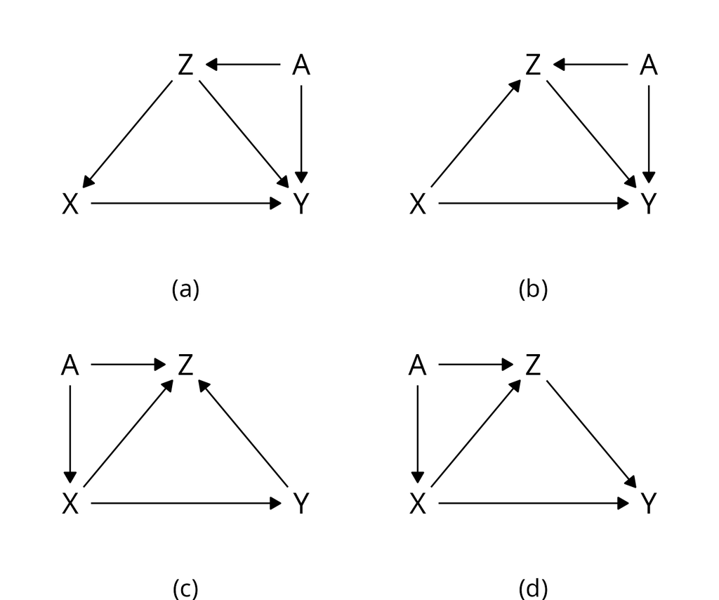

Você pode verificar suas respostas usando o pacote dagitty ou a [interface online](http://www.dagitty.net/dags.html)[^2]. Aqui está um exemplo:

```r
dag1 = dagitty('dag { X -> Y Z -> X Z -> Y A -> Z A -> Y}')

# Plotando o dag, podemos usar coordenadas para posicionar os nós na posição desejada
coordinates( dag1 ) <-
    list( x=c(X = 0, Y = 2, Z = 1, A = 2),
          y=c(X = 0, Y = 0, Z = -1, A = -1) )
plot(dag1)

# obter todos os caminhos de X para Y
paths(dag1, from = "X", to = "Y")

# obter o conjunto de ajuste correto
adjustmentSets(dag1, exposure = "X", outcome = "Y")
```

## Implicações testáveis

Não é possível provar que um DAG está correto, mas é possível refutá-lo. Todo DAG implica um conjunto de independências condicionais entre as variáveis, que podemos comparar com os dados. O dagitty lista essas independências:

```r
impliedConditionalIndependencies(dag1)
```

O resultado `A _||_ X | Z` significa que, segundo o DAG, A e X são independentes quando condicionamos em Z: todo caminho entre A e X passa por Z. Se o DAG estiver correto, o coeficiente de A em `lm(X ~ Z + A)` deve ser próximo de zero. Vamos simular dados compatíveis com o DAG e testar:

```r
set.seed(11)
N = 500
A = rnorm(N)
Z = rnorm(N, A)
X = rnorm(N, Z)
Y = rnorm(N, X + Z + A)
dados = data.frame(X, Y, Z, A)

summary(lm(X ~ Z + A))  # coeficiente de A deve ser ~0
localTests(dag1, dados) # o dagitty testa todas as implicações de uma vez
```

**Exercício**: Simule novos dados em que A também afeta X diretamente (`X = rnorm(N, Z + A)`) e repita o teste com o `dag1`. O que acontece? O que isso diz sobre o DAG?

Note que passar nesses testes não prova que o DAG está correto: vários DAGs diferentes podem implicar as mesmas independências, e alguns DAGs (como o fork em que Z afeta X e Y e X também afeta Y) não implicam nenhuma independência testável.

**Questão**: Liste as independências condicionais implicadas pelos outros três DAGs acima. Se você tivesse dados das quatro variáveis, conseguiria distinguir entre os quatro DAGs?

# O critério da porta da frente

Quando há um confundidor não observado entre X e Y, nenhum conjunto de covariáveis satisfaz o critério da porta dos fundos. Mas, em alguns casos, ainda é possível estimar o efeito de X em Y usando um mediador. Esse é o **critério da porta da frente**:

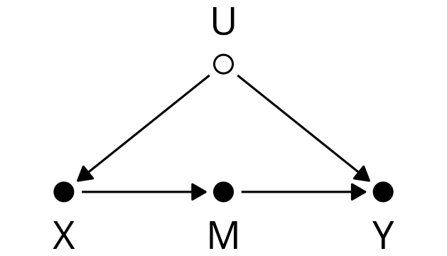

O critério exige que (1) todo o efeito de X em Y passe pelo mediador M, (2) não haja caminho de porta dos fundos aberto entre X e M, e (3) todos os caminhos de porta dos fundos entre M e Y sejam bloqueados por X. Neste DAG, podemos estimar o efeito em duas partes:

- **X → M**: o único outro caminho entre X e M é X ← U → Y ← M, que contém um colisor (Y) e está fechado. Então `lm(M ~ X)` estima o efeito de X em M.
- **M → Y**: o caminho M ← X ← U → Y é uma porta dos fundos, que é bloqueada condicionando em X. Então `lm(Y ~ M + X)` estima o efeito de M em Y.

Em um modelo linear, o efeito de X em Y é o produto dos dois efeitos:

```r
set.seed(10)
N = 1000
U = rnorm(N)
X = rnorm(N, U)
M = rnorm(N, X)
Y = rnorm(N, M + U) # efeito verdadeiro de X em Y é 1 x 1 = 1

lm(Y ~ X) |> coef() # Enviesado por U

b_xm = coef(lm(M ~ X))["X"]     # efeito de X em M
b_my = coef(lm(Y ~ M + X))["M"] # efeito de M em Y, controlando por X
b_xm * b_my                     # efeito de X em Y
```

**Questão**: Qual é o coeficiente de X em `lm(Y ~ M + X)`? Ele tem alguma interpretação causal? (Lembre da falácia da tabela 2.)

**Questão**: O exemplo clássico da porta da frente é o efeito do tabagismo (X) no câncer de pulmão (Y), mediado pelo depósito de alcatrão nos pulmões (M), com um genótipo não observado (U) afetando tabagismo e câncer, como na hipótese de Fisher. Quais suposições desse DAG você acha mais difíceis de defender?

# Variáveis instrumentais

Na seção sobre amplificação de viés, vimos que incluir Z como covariável piora a estimativa do efeito de X em Y. Como U não é observado, nenhum conjunto de covariáveis satisfaz o critério da porta dos fundos nesse DAG. Mas Z ainda carrega informação útil: Z altera X sem passar por U. Uma variável com essas propriedades é chamada de **variável instrumental**.

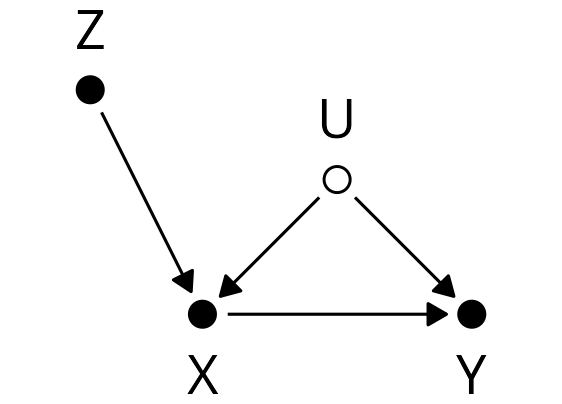

Para que Z seja um instrumento válido para o efeito de X em Y, três condições precisam ser satisfeitas:

1. **Relevância**: Z afeta X. Isso pode ser verificado nos dados.
2. **Exclusão**: Z não afeta Y a não ser através de X (não há seta Z → Y).
3. **Independência**: Z não compartilha causas com Y (não há caminho Z ← … → Y).

As condições 2 e 3 não podem ser testadas com os dados. Assim como a escolha das variáveis de controle, a validade de um instrumento depende do modelo científico.

## A ideia do instrumento

Como Z não está associado a U, a parte da variação de X causada por Z está “limpa” do confundimento. O efeito de Z em Y passa todo por X, então é igual ao efeito de Z em X multiplicado pelo efeito de X em Y. Dividindo um pelo outro, obtemos o efeito de X em Y. Vamos usar a mesma simulação da seção sobre amplificação de viés:

```r
set.seed(4)
N = 1000
Z = rnorm(N)
U = rnorm(N)
b_xz = 2
X = rnorm(N, b_xz * Z + U)
Y = rnorm(N, X + U) # efeito verdadeiro de X em Y é 1

lm(Y ~ X) |> coef()     # Enviesado por U
lm(Y ~ X + Z) |> coef() # Ainda mais enviesado (amplificação de viés)

# Estimador de razão (Wald): efeito de Z em Y dividido pelo efeito de Z em X
cov(Z, Y) / cov(Z, X)
```

Uma forma equivalente, que funciona com vários instrumentos e covariáveis, é a regressão em dois estágios: primeiro prevemos X a partir de Z, e depois usamos o valor previsto de X (que só contém a variação causada por Z) para prever Y.

```r
X_prev = fitted(lm(X ~ Z))  # 1º estágio
lm(Y ~ X_prev) |> coef()    # 2º estágio
```

(Os erros padrão do 2º estágio ajustado “na mão” estão incorretos, porque ignoram a incerteza do 1º estágio. Para a estimativa pontual não há problema.)

## Modelo Bayesiano com `ulam`

No modelo Bayesiano, ajustamos as duas equações ao mesmo tempo. O detalhe importante é que os resíduos de X e de Y são correlacionados, porque U afeta as duas variáveis. Modelamos isso com uma distribuição normal multivariada, como na seção 14.3 do *Statistical Rethinking* (2ª edição):

$$\begin{aligned}
\begin{pmatrix} Y_i \\ X_i \end{pmatrix} &\sim \mathrm{MVNormal}\left( \begin{pmatrix} \mu_{Y,i} \\ \mu_{X,i} \end{pmatrix}, \mathbf{S} \right) \\
\mu_{Y,i} &= \alpha_Y + \beta_{XY} X_i \\
\mu_{X,i} &= \alpha_X + \beta_{ZX} Z_i
\end{aligned}$$

onde $\mathbf{S}$ é a matriz de covariância dos resíduos, decomposta em desvios padrão (`Sigma`) e uma matriz de correlação (`Rho`).

```r
library(rethinking)
mIV = ulam(
  alist(
    c(Y, X) ~ multi_normal(c(muY, muX), Rho, Sigma),
    muY <- aY + bXY * X,
    muX <- aX + bZX * Z,
    c(aY, aX) ~ normal(0, 0.5),
    c(bXY, bZX) ~ normal(0, 2),
    Rho ~ lkj_corr(2),
    Sigma ~ exponential(1)
  ), data = list(X = X, Y = Y, Z = Z), chains = 4, cores = 4
)
precis(mIV, depth = 3)
```

O coeficiente `bXY` recupera o efeito causal de X em Y, e a correlação estimada entre os resíduos (`Rho[1,2]`) é a assinatura do confundidor não observado U.

**Questão**: Ajuste o mesmo modelo fixando a correlação entre os resíduos em zero (ou seja, duas regressões independentes, `Y ~ X` e `X ~ Z`)[^3]. O que acontece com a estimativa de `bXY`? Por quê?

## Instrumentos fracos

Um instrumento só funciona bem se tiver um efeito forte em X. Quando o efeito de Z em X é pequeno, o denominador do estimador de razão fica próximo de zero, e a estimativa fica muito imprecisa.

**Exercício**: Repita a simulação muitas vezes para diferentes valores de `b_xz` e compare a distribuição das estimativas:

```r
estima_iv = function(b_xz, N = 200) {
  Z = rnorm(N)
  U = rnorm(N)
  X = rnorm(N, b_xz * Z + U)
  Y = rnorm(N, X + U)
  cov(Z, Y) / cov(Z, X)
}
set.seed(1)
est_forte = replicate(1000, estima_iv(b_xz = 2))
est_fraco = replicate(1000, estima_iv(b_xz = 0.1))
quantile(est_forte, c(0.05, 0.5, 0.95))
quantile(est_fraco, c(0.05, 0.5, 0.95))
```

Compare com o exercício de amplificação de viés: o mesmo parâmetro `b_xz` que torna Z um controle catastrófico torna Z um bom instrumento.

## Exemplos biológicos

### Randomização mendeliana

Na epidemiologia genética, alelos são usados como instrumentos. Suponha que queremos saber se o nível de colesterol (X) causa doença cardíaca (Y). Fatores como dieta e estilo de vida (U) afetam as duas variáveis, e não são bem medidos. Mas existem alelos (Z) que alteram o nível de colesterol. Como os alelos são herdados aleatoriamente dos pais (segregação mendeliana), eles não deveriam estar associados à dieta ou ao estilo de vida: a natureza fez o sorteio do experimento por nós. Essa abordagem é chamada de **randomização mendeliana**.

**Questão**: A pleiotropia (um mesmo gene afetando vários caracteres) é uma das principais preocupações na randomização mendeliana. Qual das três condições de um instrumento válido ela pode violar? Desenhe o DAG.

**Questão**: Pense em um exemplo de variável instrumental na sua área de pesquisa. Ela satisfaz as três condições?

### Intervenção em campo

Em experimentos de campo, a intervenção nem sempre produz o tratamento pretendido. Considere um experimento para avaliar o controle biológico de pragas do café por aves insetívoras. Em uma plantação, sorteia-se uma parte dos pés de café para ser coberta por telas que impedem o acesso das aves. Os demais ficam sem tela, como controle. A variável resposta é a produção de grãos de cada planta. Para medir a predação, em cada planta são colocados modelos de lagartas feitos de massa de modelar. A proporção de modelos removidos ou com marcas de bico serve como índice da atividade de aves insetívoras na planta.

O tratamento, porém, não sai exatamente como planejado. Algumas telas são rompidas por animais ou pelo tempo, e as aves passam a forragear nessas plantas. Já nas plantas sem tela, a atividade das aves varia muito por causa de diferenças não controladas entre as plantas, como tamanho, posição na plantação e microclima, que também podem afetar a produção de frutos.

Para estimar o efeito da atividade das aves sobre a produção de café, usa-se como instrumento a variável binária que indica se a planta foi telada, no início do experimento.

**Questão**: que premissas são necessárias para que a tela seja um instrumento válido? Alguma delas é questionável neste experimento?

**Questão** : o que estima um modelo da produção apenas em função da tela? Para que tipo de pergunta essa estimativa seria a mais útil?

**Questão** : qual é o problema de estimar o efeito da atividade das aves com uma regressão da produção apenas na atividade das aves, sem usar o instrumento?

# Extra: modelos “de luxo” (full luxury models)

Em alguns casos, podemos querer estimar o modelo causal completo, incluindo todas as relações do DAG que conecta X e Y, e não apenas o efeito de X em Y. Esse tipo de modelo é chamado de *full luxury model* por McElreath, e é essencialmente um modelo de equações estruturais (SEM) Bayesiano.

Vamos simular dados a partir do seguinte DAG e tentar ajustar um modelo completo:

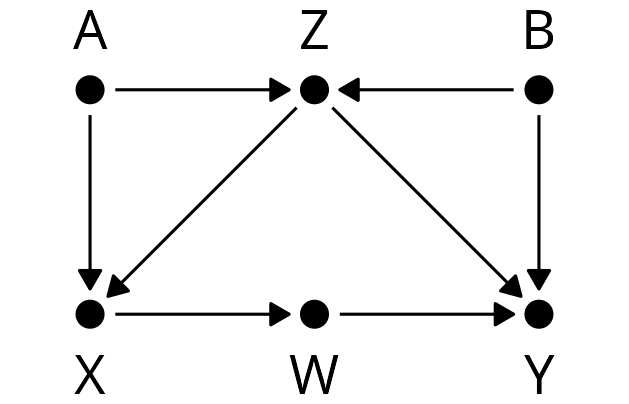

O efeito de X em Y é mediado por W. Use o dagitty para encontrar o conjunto de ajuste:

```r
library(dagitty)
dag2 = dagitty('dag { X -> W W -> Y Z -> X Z -> Y A -> Z A -> X B -> Z B -> Y }')
adjustmentSets(dag2, exposure = "X", outcome = "Y")
```

Agora simulamos dados com todos os efeitos iguais a 1, de modo que o efeito causal de X em Y (através de W) também é igual a 1:

```r
set.seed(2)
N = 200
A = rnorm(N)
B = rnorm(N)
Z = rnorm(N, A + B)
X = rnorm(N, A + Z)
W = rnorm(N, X)
Y = rnorm(N, W + Z + B)
df = data.frame(X, Y, Z, W, A, B)
```

Existem dois conjuntos de ajuste mínimos para estimar o efeito de X em Y: {Z, B} e {A, Z}. Note que condicionar apenas em Z não é suficiente: Z é um colisor no caminho X ← A → Z ← B → Y, e condicionar em Z abre esse caminho, que precisa ser fechado com A ou B. Vamos usar {Z, B}:

```r
lm(Y ~ X + Z + B, data = df) |> coef()
```

Essa regressão já dá a estimativa correta, mas podemos ir além e ajustar o DAG inteiro, com uma equação para cada variável em função dos seus pais. Na maior parte das vezes isso não é necessário, mas é um bom exercício para entender as implicações do DAG, e permite estimar todos os efeitos de uma só vez:

```r
library(rethinking)
mFull = ulam(
  alist(
    A ~ normal(aA, sA),
    B ~ normal(aB, sB),
    Z ~ normal(aZ + bAZ * A + bBZ * B, sZ),
    X ~ normal(aX + bAX * A + bZX * Z, sX),
    W ~ normal(aW + bXW * X, sW),
    Y ~ normal(aY + bWY * W + bZY * Z + bBY * B, sY),
    c(bAZ, bAX, bBZ, bZX, bZY, bBY, bXW, bWY) ~ normal(0, 0.3),
    c(aA, aB, aZ, aX, aY, aW) ~ normal(0, 1),
    c(sA, sB, sX, sY, sZ, sW) ~ exponential(1)
  ), data = df, chains = 4, cores = 4, iter = 2000
)
plot(precis(mFull, prob = 0.95))
abline(v = 1, col = 2)
```

Neste modelo não existe um parâmetro único para o efeito de X em Y. O efeito causal de X em Y passa por W, e é o produto dos efeitos ao longo do caminho, `bXW * bWY`. Podemos calcular a distribuição posterior desse efeito a partir das amostras:

```r
post = extract.samples(mFull)
efeito_XY = post$bXW * post$bWY
precis(efeito_XY, prob = 0.95)
dens(efeito_XY, xlab = "Efeito causal de X em Y")
abline(v = 1, col = 2)
```

**Desafio**: E se B não fosse observado? Para estimar apenas o efeito de X em Y, o conjunto {A, Z} continua disponível (confira com o dagitty, declarando `B [latent]`). Mas e o modelo completo? Como poderíamos continuar ajustando o DAG inteiro mesmo sem observar B? (Dica: no modelo Bayesiano, uma variável não observada pode ser tratada como um parâmetro, um valor desconhecido para cada observação.)

```r
# B não observado
df_semB = data.frame(X, Y, W, A, Z)
```

[^1]: Note que um caminho é apenas uma conexão por via de uma ou mais setas, independente do sentido de cada seta.
[^2]: Para iniciantes, recomendamos começar brincando com esta interface, e depois verificar os resultados com o pacote `dagitty`
[^3]: Um modelo com as correlações iguais a zero equivale a um modelo com duas verossimilhanças separadas, para cada regressão. Ou, se quiser manter a normal multivariada, decalre o valor da matriz Rho nos dados: `data = list(X = X, Y = Y, Z = Z, Rho = diag(2)), chains = 4, cores = 4)`